# Tugas UTS

Angga Fathan Rofiqy

27 February, 2024

# Resampling Jackknife

## Pendahuluan

Proses **pendugaan parameter** selalu didasari dengan **asumsi sebaran** dan **ukuran contoh** yang memadai. **Asumsi sebaran** ini menjadi dasar penentuan **selang kepercayaan** bagi parameter (misal 𝜇). Selang kepercayaan bagi 𝜇 juga **bisa diperoleh** meskipun **contoh acak berukuran kecil** tetapi kita mengasumsikan populasinya memiliki **sebaran Normal**. Seandainya contoh acak berukuran kecil dan sebaran populasinya tidak diketahui, selang kepercayaan bagi parameter **tidak bisa diperoleh** tanpa sebaran.

Contoh acak **berukuran kecil** tidak jarang diperoleh dan bahkan **tidak ada informasi** tentang **sebarannya**. Pendugaan selang bagi parameter harus dengan metode yang didasarkan pada asumsi sebaran. Sebaran populasi data tidak diketahui sehingga kita tidak mempunyai dasar yang kuat untuk menduga selang kepecayaan tanpa sebaran.

> Jadi inti permasalahan nya adalah ketika n berukuran kecil, karena:
- Ukuran **n kecil** mengakibatkan beberapa **teori peluang** dan **statistika inferensia** **tidak terpenuhi**.
- Ukuran **n kecil** juga menjadi per**masalah**an dalam suatu **pendugaan parameter** yang berkaitan dengan **tingkat keakuratan dan ketelitian**.
- Ukuran **n kecil** mengakibatkan Tidak adanya informasi mengenai sebaran populasi.
- Ukuran **n kecil** memiliki masalah dalam Pengujian Hipotesis.

> **Jackknife** dapat digunakan sebagai cara **pendugaan selang** dalam kondisi **data berukuran kecil** dan **tidak memenuhi asumsi sebaran**.

Sama seperti metode bootstrap, Ide dasar dari jackknife adalah **membangun data semu** dengan menggunakan informasi data asli. Sehingga kita bisa memperoleh **n** yang lebih **besar**. Metode ini menjadi sebuah metode yang efisien untuk mendapatkan **hasil yang robust**.

### Tujuan

Pada awalnya metode jackknife atau leave-one-out **bertujuan** untuk **menduga bias** dari suatu penduga yang diperkenalkan oleh Maurice Quenouille pada tahun 1949 dan dikembangkan oleh John Tukey pada tahun 1957, yang dikenal dengan Quenouille-Tukey Jackknife. Metode jackknife **serupa** dengan metode **bootstrap** untuk **galat baku**. Metode ini **seperti tipe validasi silang leave-one-out**. Bila 𝒙=(𝑥1, 𝑥2, …, 𝑥𝑛) adalah contoh acak dan 𝒙((𝒊)) adalah subset dari 𝒙 tanpa pengamatan 𝑥𝑖, yaitu 𝒙((𝒊))=(𝑥1, …,𝑥((𝑖−1) ), 𝑥((𝑖+1) ), …, 𝑥𝑛). Jika 𝜃 duga=𝑓𝑛 (𝒙), maka definisikan bahwa 𝜃 duga=𝑓(𝑛−1) ( 𝒙((𝒊) ) ), 𝑖=1, 2, …, 𝑛.

# Kasus 1

## Data

Tabel di bawah ini melaporkan jumlah populasi dari n=49 kota di USA pada tahun 1920 dan 1930, yang dinotasikan dengan u dan x.

```r
# Import data ke R
dataCity <- read.table(header = TRUE,text=
'u  x
138 143
93  104
61  69
179 260
48  75
37  63
29  50
23  48
30  111
2   50
38  52
46  53
71  79
25  57
298 317
74  93
50  58
76  80
381 464
387 459
78  106
60  57
507 634
50  64
77  89
64  77
40  60
136 139
243 291
256 288
94  85
36  46
45  53
67  67
120 115
172 183
66  86
46  65
121 113
44  58
64  63
56  142
40  64
116 130
87  105
43  61
43  50
161 232
36  54
')
str(dataCity)
```

```
## 'data.frame':    49 obs. of  2 variables:
##  $ u: int  138 93 61 179 48 37 29 23 30 2 ...
##  $ x: int  143 104 69 260 75 63 50 48 111 50 ...
```

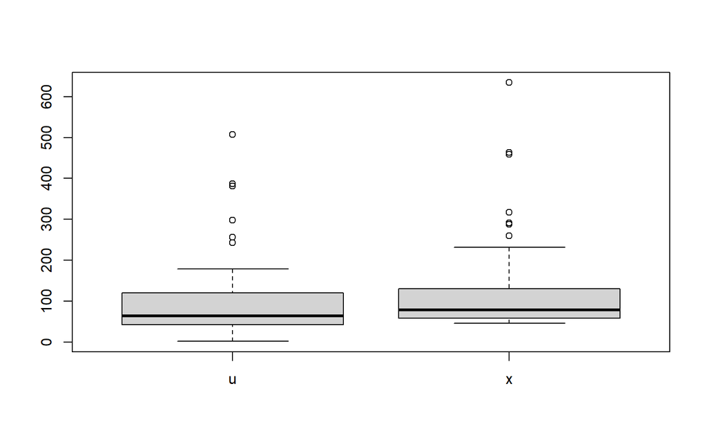

```r
boxplot(dataCity)
```

## Hasil

> 1. Bangkitan sampel baru dengan **menghilangkan satu amatan** pada setiap ulangan.

Sehingga banyaknya ulangan yang dapat dilakukan adalah sebanyak n.

```r
n <- nrow(dataCity)
# menghilangkan satu amatan
removeOne <- function(i,data) seq(nrow(data))[-i]
set.seed(123)
index <- sapply(1:n, removeOne, data=dataCity)
```

> 2. Hitung penduga untuk setiap sampel baru

```r
#penduga theta
thetaHat <- function(data) mean(data$x) / ( mean(data$x) +mean(data$u) )
thetaJack <- NULL
for (i in 1:n){
thetaJack <- c(thetaJack, thetaHat(dataCity[index[ ,i], ]))
}
thetaJack
```

```
##  [1] 0.5545084 0.5538268 0.5536385 0.5518066 0.5527562 0.5526926 0.5528166
##  [8] 0.5526012 0.5504251 0.5514915 0.5531801 0.5535348 0.5537346 0.5523411
## [15] 0.5555556 0.5533232 0.5535332 0.5539427 0.5537198 0.5542502 0.5530004
## [22] 0.5540673 0.5531204 0.5532941 0.5536323 0.5534676 0.5529601 0.5545693
## [29] 0.5537934 0.5545860 0.5546377 0.5533203 0.5534855 0.5540154 0.5547333
## [36] 0.5546027 0.5532067 0.5530567 0.5548637 0.5532370 0.5540263 0.5504587
## [43] 0.5528006 0.5539295 0.5534880 0.5530681 0.5535062 0.5520461 0.5530020
```

```r
mean(thetaJack)
```

```
## [1] 0.5533807
```

> 3. Gunakan hasil pada langkah 1 untuk menghitung ragam V(θduga). Ragam V(θduga) bisa didekati menggunakan ragam jacknife V(θ^(Jack)).

```r
# ragam
ragamTheta2 <- (((n-1)^2)/n)*var(thetaJack)
ragamTheta2
```

```
## [1] 4.762324e-05
```

```r
# standard error
sqrt(ragamTheta2)
```

```
## [1] 0.00690096
```

# Kasus 2

Metode Jackknife menggunakan **partisi sistematis** dari kumpulan data untuk **mengestimasi properti** dari **estimator** dihitung dari **sampel penuh**. Quenouille (1949, 1956) menyarankan teknik untuk memperkirakan (dan, karenanya, **mengurangi**) **bias** dari suatu penduga. Tukey (1958) menciptakan istilah **pisau lipat** untuk merujuk pada metode, dan juga menunjukkan bahwa metode tersebut berguna dalam **mengestimasi varian** dari suatu penduga.

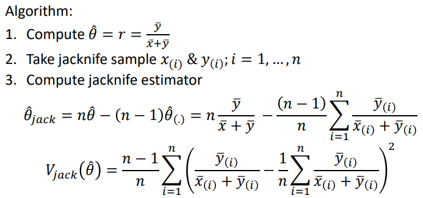

## Data

```r
store <- LETTERS[1:5]
item1 <- c(999, 1432, 969, 1548, 1557)
item2 <- c(1164, 1424, 1043, 870, 1101)
d1 <- data.frame(store, item1, item2)
d1
```

```
##   store item1 item2
## 1     A   999  1164
## 2     B  1432  1424
## 3     C   969  1043
## 4     D  1548   870
## 5     E  1557  1101
```

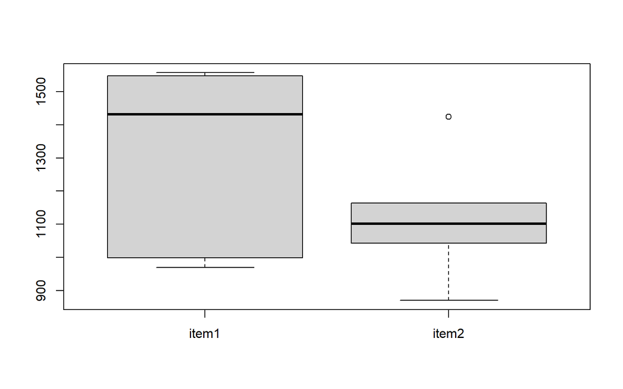

```r
boxplot(d1[,-1])
```

```r
n <- nrow(d1)
#1. Hitung Teta Duga
teta_hat <- mean(d1$item1)/ ( mean(d1$item1) +mean(d1$item2) )

#2. Jacknife Sampling
y <- matrix(NA, n, n-1)
x <- matrix(NA, n, n-1)
for (i in 1:n) {
  y[i,] <- d1$item1[-i]
  x[i,] <- d1$item2[-i]
}
ybar <- apply(y, 1, mean)
xbar <- apply(x, 1, mean)

#3. Menghitung Jacknife Estimator
teta_i <- ybar/ (xbar+ybar)
teta_jk <- n *teta_hat -(n-1) *mean(teta_i)
var_jk <- (n-1)/ n *sum( (teta_i - mean(teta_i))^2 )
se_jk <- sqrt(var_jk)
teta_jk; var_jk; se_jk
```

```
## [1] 0.5378795
```

```
## [1] 0.001088501
```

```
## [1] 0.03299243
```

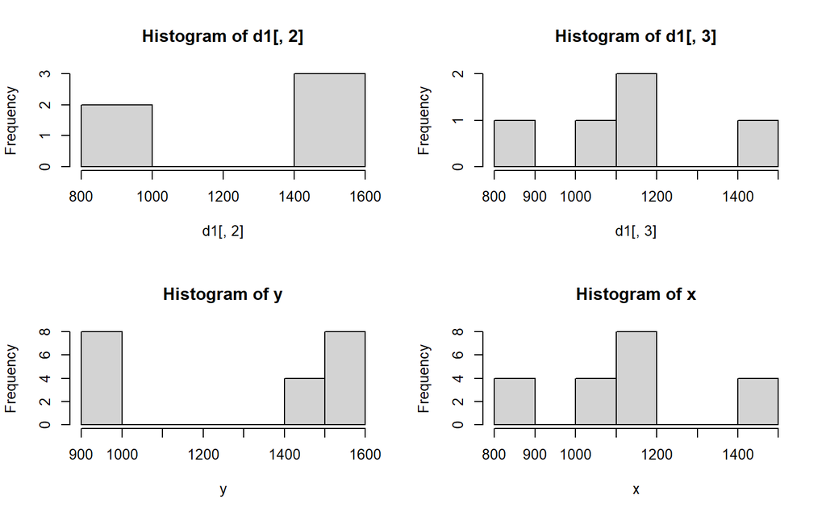

```r
par(mfrow=c(2,2))
hist(d1[,2]); hist(d1[,3])
hist(y); hist(x)
```

# Kasus 1 cara 2

```r
d1 <- dataCity
n <- nrow(d1)
teta_hat <- mean(d1[,1])/ (mean(d1[,1]) +mean(d1[,2]))
y <- matrix(NA, n, n-1)
x <- matrix(NA, n, n-1)

for (i in 1:n) {
  y[i,] <- d1[,1][-i]
  x[i,] <- d1[,2][-i]
}

ybar <- apply(y, 1, mean)
xbar <- apply(x, 1, mean)

teta. <- ybar/ (xbar +ybar)
teta_jk <-n *teta_hat -(n-1) *mean(teta.)

var_jk <- (n-1)/ n *(sum(teta.^2) -(n *mean(teta.)^2))
se_jk <- sqrt(var_jk)

teta_jk; var_jk; se_jk
```

```
## [1] 0.4468611
```

```
## [1] 4.762324e-05
```

```
## [1] 0.00690096
```

Bandingkan dengan cara 1:

```r
ragamTheta2; sqrt(ragamTheta2)
```

```
## [1] 4.762324e-05
```

```
## [1] 0.00690096
```

Sebaran

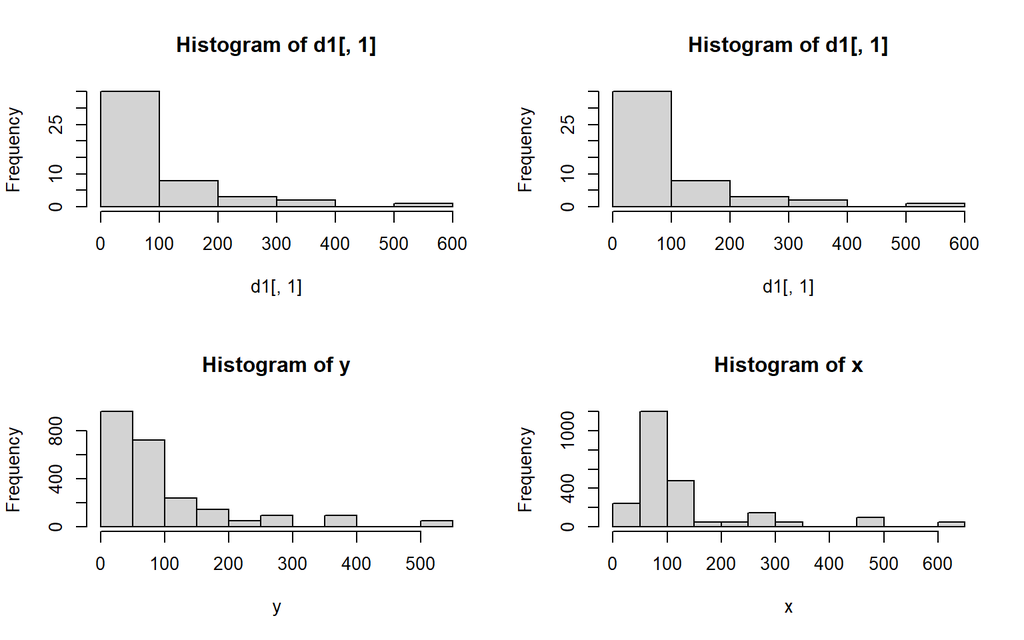

```r
par(mfrow=c(2,2))
hist(d1[,1]); hist(d1[,1])
hist(y); hist(x)
```